# Drake_Zhou_Part_03_C

Drake Zhou

4/26/2022

# Overview & Initialization

You must make predictions with your 2 selected generalized linear models in order to visualize the trends of the event probability with respect to the inputs.

## Package Import

```r
library(tidyverse)
library(caret)
library(coefplot)
library(rstanarm)
library(splines)
```

## Data Import

```r
df_all <- readr::read_csv("final_project_train.csv", col_names = TRUE)
# Input standarize
standard_df_all <- df_all %>%
  select(starts_with("x")) %>%
  # scale(center = TRUE, scale = TRUE) %>%
  # as.data.frame() %>%
  # tibble::as_tibble() %>%
  mutate(obs = if_else(df_all$outcome == 'event',1,0),
         region = df_all$region,
         customer = df_all$customer)

# Resampling
train_id <- sample(1:nrow(standard_df_all), size = floor(0.8 * nrow(standard_df_all)))
train_ready <- standard_df_all %>% slice(train_id)
test_ready <- standard_df_all %>% slice(-train_id)
```

# Visualization

## Input grid prepare

```r
make_test_input_list <- function(var_name, top_4_inputs, all_data)
{
  xvar <- all_data %>% select(all_of(var_name)) %>% pull()

  if (var_name %in% top_4_inputs[1]){
    # use 25 unique values between the min/max values
    xgrid <- seq(min(xvar), max(xvar), length.out = 25)
  } else if (var_name %in% top_4_inputs[2]){
    # specify quantiles to use
    xgrid <- quantile(xvar, probs = c(0.05, 0.25, 0.5, 0.75, 0.95), na.rm = TRUE)
    xgrid <- as.vector(xgrid)
  } else {
    # set to their median values
    xgrid <- median(xvar, na.rm = TRUE)
  }

  return(xgrid)
}
```

The second function, make_test_input_grid(), is a wrapper function. It iteratively applies the make_test_input_list() function to all inputs and then uses the expand.grid() function to create full factorial grid based on the list of unique input values.

```r
make_test_input_grid <- function(all_input_names, top_4_inputs, all_data)
{
  test_list <- purrr::map(all_input_names,
                          make_test_input_list,
                          top_4_inputs = top_4_inputs,
                          all_data = all_data)

  expand.grid(test_list,
              KEEP.OUT.ATTRS = FALSE,
              stringsAsFactors = FALSE) %>%
    purrr::set_names(all_input_names)
}
```

```r
my_input_names <- standard_df_all %>% dplyr::select(-obs) %>% names()
my_top_ranked_inputs <- c("xb_07","xw_01")

viz_input_grid <- make_test_input_grid(my_input_names, my_top_ranked_inputs, standard_df_all)
```

## Model Import

```r
rstanarm_cat_mod3 <- readr::read_rds('models/rstanarm_cat_mod3.rds')
rstanarm_cat_mod9 <- readr::read_rds('models/rstanarm_cat_mod9.rds')
```

## Model #3

Make prediction

```r
post_pred_mod3 <- posterior_predict(rstanarm_cat_mod3, newdata = viz_input_grid)
```

Visualize predict result

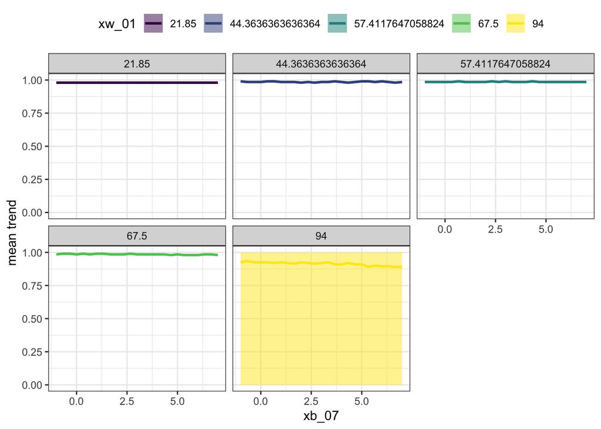

```r
post_pred_mod3 %>%
  as.data.frame() %>% tibble::as_tibble() %>%
  tibble::rowid_to_column("post_id") %>%
  tidyr::gather(key = "pred_id", value = "value", -post_id) %>%
  mutate_at(c("pred_id"), as.numeric) %>%
  group_by(pred_id) %>%
  summarise(num_post = n(),
            trend_avg = mean(value),
            trend_lwr = quantile(value, 0.05),
            trend_upr = quantile(value, 0.95)) %>%
  ungroup() %>%
  left_join(viz_input_grid %>% tibble::rowid_to_column("pred_id"),
            by = "pred_id") %>%
  ggplot(mapping = aes(x = xb_07)) +
  geom_ribbon(mapping = aes(ymin = trend_lwr,
                            ymax = trend_upr,
                            group = xw_01,
                            fill = as.factor(xw_01)),
              alpha = 0.5) +
  geom_line(mapping = aes(y = trend_avg,
                          group = xw_01,
                          color = as.factor(xw_01)),
            size = 1.) +
  facet_wrap(~xw_01, scales = 'fixed')+
  scale_fill_viridis_d("xw_01") +
  scale_color_viridis_d("xw_01") +
  labs(y = "mean trend") +
  theme_bw() +
  theme(legend.position = "top")
```

You MUST include the predicted mean event probability and the confidence interval whether you use non-Bayesian or Bayesian models.

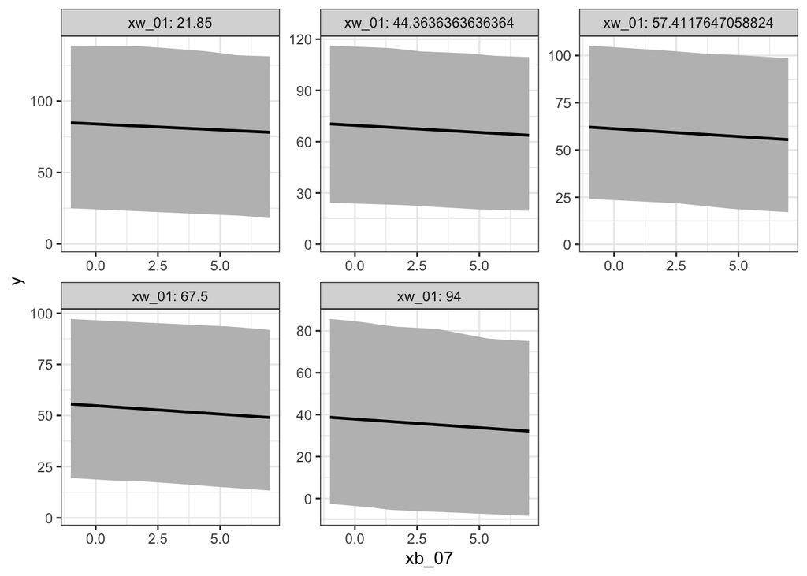

```r
post_pred_mod3 %>%
  as.data.frame() %>% tibble::as_tibble() %>%
  tibble::rowid_to_column("post_id") %>%
  tidyr::gather(key = "pred_id", value = "value", -post_id) %>%
  mutate_at(c("pred_id"), as.numeric) %>%
  group_by(pred_id) %>%
  summarise(y_avg = mean(value),
            y_lwr = quantile(value, 0.05),
            y_upr = quantile(value, 0.95)) %>%
  ungroup() %>%
  left_join(posterior_linpred(rstanarm_cat_mod3, newdata = viz_input_grid) %>%
              as.data.frame() %>% tibble::as_tibble() %>%
              tibble::rowid_to_column("post_id") %>%
              tidyr::gather(key = "pred_id", value = "value", -post_id) %>%
              mutate_at(c("pred_id"), as.numeric) %>%
              group_by(pred_id) %>%
              summarise(trend_avg = mean(value),
                        trend_lwr = quantile(value, 0.05),
                        trend_upr = quantile(value, 0.95)) %>%
              ungroup(),
            by = "pred_id") %>%
  left_join(viz_input_grid %>% tibble::rowid_to_column("pred_id"),
            by = "pred_id") %>%
  ggplot(mapping = aes(x = xb_07)) +
  geom_ribbon(mapping = aes(ymin = y_lwr, ymax = y_upr,
                            group = xw_01),
              fill = "darkorange") +
  geom_ribbon(mapping = aes(ymin = trend_lwr, ymax = trend_upr,
                            group = xw_01),
              fill = "grey") +
  geom_line(mapping = aes(y = trend_avg,
                          group = xw_01),
            color = "black", size = 0.85) +
  facet_wrap(~xw_01, labeller = "label_both", scales = 'free') +
  labs(y = "y") +
  theme_bw()
```

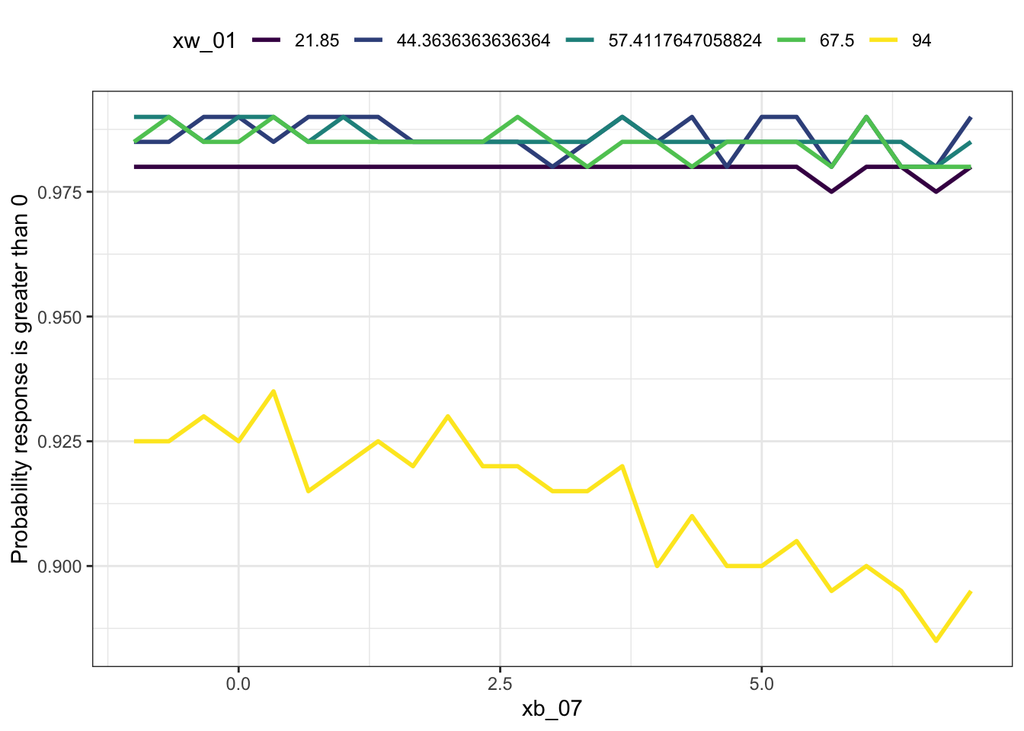

```r
posterior_predict(rstanarm_cat_mod3, newdata = viz_input_grid) %>%
  as.data.frame() %>% tibble::as_tibble() %>%
  tibble::rowid_to_column("post_id") %>%
  tidyr::gather(key = "pred_id", value = "value", -post_id) %>%
  mutate_at(c("pred_id"), as.numeric) %>%
  group_by(pred_id) %>%
  summarise(num_post = n(),
            y_avg = mean(value),
            y_lwr = quantile(value, 0.05),
            y_upr = quantile(value, 0.95),
            prob_grt_0 = mean(value > 0)) %>%
  ungroup() %>%
  left_join(viz_input_grid %>% tibble::rowid_to_column("pred_id"),
            by = "pred_id") %>%
  ggplot(mapping = aes(x = xb_07, y = prob_grt_0)) +
  geom_line(mapping = aes(group = xw_01,
                          color = as.factor(xw_01)),
            size = 1.) +
  scale_fill_viridis_d("xw_01") +
  scale_color_viridis_d("xw_01") +
  labs(y = "Probability response is greater than 0") +
  theme_bw() +
  theme(legend.position = "top")
```

## Model #9

You must visualize your predictive trends using the following style: • The primary input should be used as the x-aesthetic in a graphic. • The secondary input should be used as a facet variable –it is recommended to use 4 to 6 unique values if your secondary input is a continuous variable. • You must decide what values to use for the remaining inputs.

Make prediction

```r
post_pred_mod9 <- posterior_predict(rstanarm_cat_mod9, newdata = viz_input_grid)
```

Visualize predict result

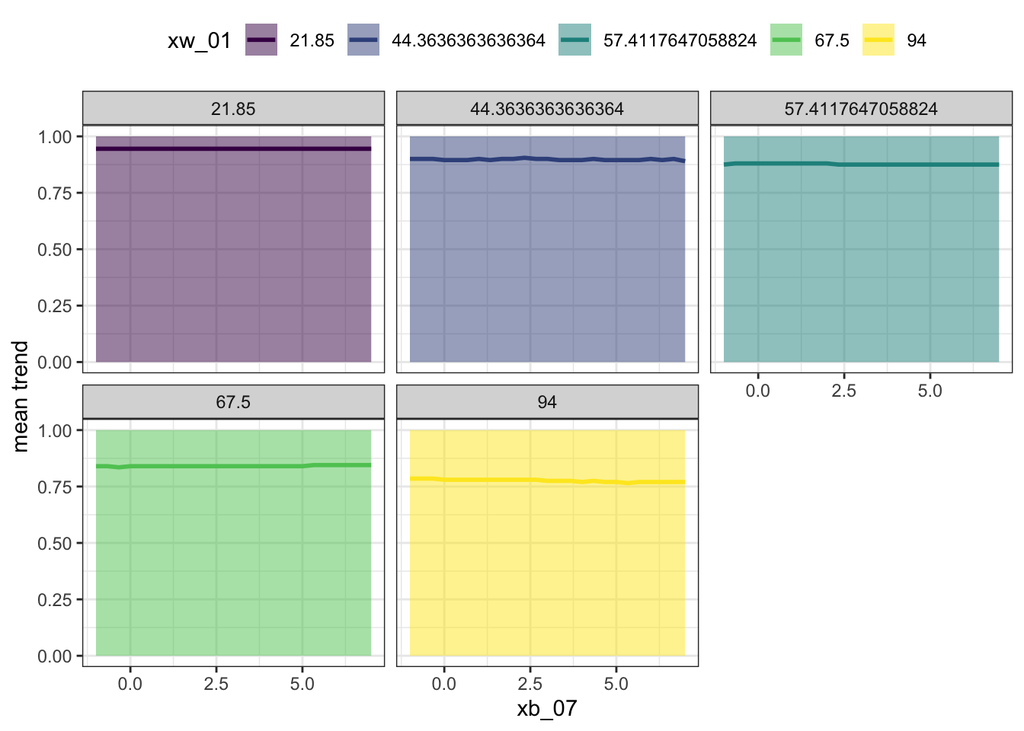

```r
post_pred_mod9 %>%
  as.data.frame() %>% tibble::as_tibble() %>%
  tibble::rowid_to_column("post_id") %>%
  tidyr::gather(key = "pred_id", value = "value", -post_id) %>%
  mutate_at(c("pred_id"), as.numeric) %>%
  group_by(pred_id) %>%
  summarise(num_post = n(),
            trend_avg = mean(value),
            trend_lwr = quantile(value, 0.05),
            trend_upr = quantile(value, 0.95)) %>%
  ungroup() %>%
  left_join(viz_input_grid %>% tibble::rowid_to_column("pred_id"),
            by = "pred_id") %>%
  ggplot(mapping = aes(x = xb_07)) +
  geom_ribbon(mapping = aes(ymin = trend_lwr,
                            ymax = trend_upr,
                            group = xw_01,
                            fill = as.factor(xw_01)),
              alpha = 0.5) +
  geom_line(mapping = aes(y = trend_avg,
                          group = xw_01,
                          color = as.factor(xw_01)),
            size = 1.) +
  facet_wrap(~xw_01, scales = 'fixed')+
  scale_fill_viridis_d("xw_01") +
  scale_color_viridis_d("xw_01") +
  labs(y = "mean trend") +
  theme_bw() +
  theme(legend.position = "top")
```

You MUST include the predicted mean event probability and the confidence interval whether you use non-Bayesian or Bayesian models.

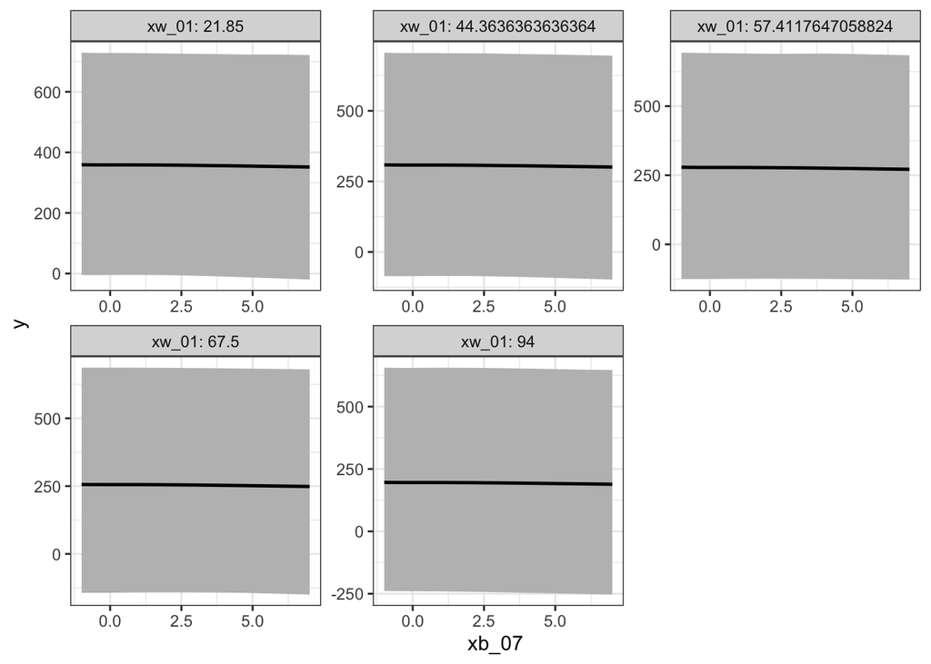

```r
post_pred_mod9 %>%
  as.data.frame() %>% tibble::as_tibble() %>%
  tibble::rowid_to_column("post_id") %>%
  tidyr::gather(key = "pred_id", value = "value", -post_id) %>%
  mutate_at(c("pred_id"), as.numeric) %>%
  group_by(pred_id) %>%
  summarise(y_avg = mean(value),
            y_lwr = quantile(value, 0.05),
            y_upr = quantile(value, 0.95)) %>%
  ungroup() %>%
  left_join(posterior_linpred(rstanarm_cat_mod9, newdata = viz_input_grid) %>%
              as.data.frame() %>% tibble::as_tibble() %>%
              tibble::rowid_to_column("post_id") %>%
              tidyr::gather(key = "pred_id", value = "value", -post_id) %>%
              mutate_at(c("pred_id"), as.numeric) %>%
              group_by(pred_id) %>%
              summarise(trend_avg = mean(value),
                        trend_lwr = quantile(value, 0.05),
                        trend_upr = quantile(value, 0.95)) %>%
              ungroup(),
            by = "pred_id") %>%
  left_join(viz_input_grid %>% tibble::rowid_to_column("pred_id"),
            by = "pred_id") %>%
  ggplot(mapping = aes(x = xb_07)) +
  geom_ribbon(mapping = aes(ymin = y_lwr, ymax = y_upr,
                            group = xw_01),
              fill = "darkorange") +
  geom_ribbon(mapping = aes(ymin = trend_lwr, ymax = trend_upr,
                            group = xw_01),
              fill = "grey") +
  geom_line(mapping = aes(y = trend_avg,
                          group = xw_01),
            color = "black", size = 0.85) +
  facet_wrap(~xw_01, labeller = "label_both", scales = 'free') +
  labs(y = "y") +
  theme_bw()
```

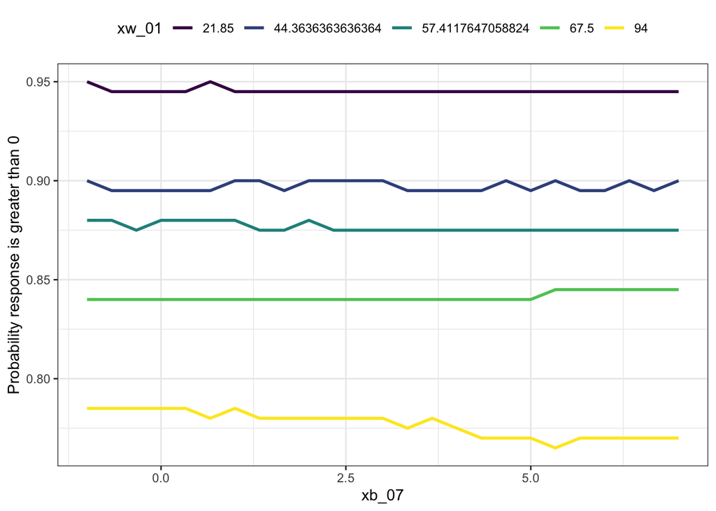

```r
posterior_predict(rstanarm_cat_mod9, newdata = viz_input_grid) %>%
  as.data.frame() %>% tibble::as_tibble() %>%
  tibble::rowid_to_column("post_id") %>%
  tidyr::gather(key = "pred_id", value = "value", -post_id) %>%
  mutate_at(c("pred_id"), as.numeric) %>%
  group_by(pred_id) %>%
  summarise(num_post = n(),
            y_avg = mean(value),
            y_lwr = quantile(value, 0.05),
            y_upr = quantile(value, 0.95),
            prob_grt_0 = mean(value > 0)) %>%
  ungroup() %>%
  left_join(viz_input_grid %>% tibble::rowid_to_column("pred_id"),
            by = "pred_id") %>%
  ggplot(mapping = aes(x = xb_07, y = prob_grt_0)) +
  geom_line(mapping = aes(group = xw_01,
                          color = as.factor(xw_01)),
            size = 1.) +
  scale_fill_viridis_d("xw_01") +
  scale_color_viridis_d("xw_01") +
  labs(y = "Probability response is greater than 0") +
  theme_bw() +
  theme(legend.position = "top")
```

# Conclusion

```
Clearly, they are not consistent with each other.
```